# Electricity Report

unaltugba

11&11&2020

## About Data

This dataset consists of six different values in September 2020:

- Date
- MCP: Market clearing price
- SMP: System Marginal Price
- Positive Imbalance Price: min(PTF,SMF)*0,97
- Negative Imbalance Price: max(PTF,SMF)*1,03
- SMP Direction : Energy Surplus or Energy Deficit

You can find the data [here](https://rapor.epias.com.tr/rapor/xhtml/ptfSmfListeleme.xhtml)

## Data Analysis

```r
library(dplyr)
library(ggplot2)
library(readxl)
library(lubridate)
```

```r
energy_data<-read_excel("C:/Users/unalt/Desktop/MEF/Data Analytics Essentials/week3/ptf-smf.xlsx")
summary(energy_data)
```

```
##       Date                          MCP             SMP
##  Min.   :2020-09-01 00:00:00   Min.   :198.4   Min.   : 129.0
##  1st Qu.:2020-09-08 11:45:00   1st Qu.:292.7   1st Qu.: 275.0
##  Median :2020-09-15 23:30:00   Median :305.1   Median : 320.0
##  Mean   :2020-09-15 23:30:00   Mean   :308.2   Mean   : 323.4
##  3rd Qu.:2020-09-23 11:15:00   3rd Qu.:314.9   3rd Qu.: 351.3
##  Max.   :2020-09-30 23:00:00   Max.   :982.0   Max.   :2000.0
##  PositiveImbalancePrice(TL/MWh) NegativeImbalancePrice(TL/MWh)
##  Min.   :125.1                  Min.   : 204.7
##  1st Qu.:258.0                  1st Qu.: 305.4
##  Median :293.8                  Median : 330.9
##  Mean   :286.8                  Mean   : 346.1
##  3rd Qu.:304.8                  3rd Qu.: 365.0
##  Max.   :952.5                  Max.   :2060.0
##  SMPDirection
##  Length:720
##  Class :character
##  Mode  :character
##
##
##
```

### Data Manipulations

```r
new_energy_data<- energy_data %>%
  transform(Date = as.POSIXct(Date, format='%d.%m.%y %H:%M')) %>%
  mutate(New_Date= as.Date(Date)) %>%
  mutate(Day = weekdays(Date)) %>% mutate(SMP_MCP_Diff=SMP-MCP) %>%
  mutate(Time= format(energy_data$Date,"%H:%M:%S")) %>%
  mutate(Hour=lubridate::hour(Date))

summary(new_energy_data)
```

```
##       Date                          MCP             SMP
##  Min.   :2020-09-01 00:00:00   Min.   :198.4   Min.   : 129.0
##  1st Qu.:2020-09-08 11:45:00   1st Qu.:292.7   1st Qu.: 275.0
##  Median :2020-09-15 23:30:00   Median :305.1   Median : 320.0
##  Mean   :2020-09-15 23:30:00   Mean   :308.2   Mean   : 323.4
##  3rd Qu.:2020-09-23 11:15:00   3rd Qu.:314.9   3rd Qu.: 351.3
##  Max.   :2020-09-30 23:00:00   Max.   :982.0   Max.   :2000.0
##  PositiveImbalancePrice.TL.MWh. NegativeImbalancePrice.TL.MWh.
##  Min.   :125.1                  Min.   : 204.7
##  1st Qu.:258.0                  1st Qu.: 305.4
##  Median :293.8                  Median : 330.9
##  Mean   :286.8                  Mean   : 346.1
##  3rd Qu.:304.8                  3rd Qu.: 365.0
##  Max.   :952.5                  Max.   :2060.0
##  SMPDirection          New_Date              Day             SMP_MCP_Diff
##  Length:720         Min.   :2020-09-01   Length:720         Min.   :-180.99
##  Class :character   1st Qu.:2020-09-08   Class :character   1st Qu.:   0.00
##  Mode  :character   Median :2020-09-15   Mode  :character   Median :  18.25
##                     Mean   :2020-09-15                      Mean   :  15.21
##                     3rd Qu.:2020-09-23                      3rd Qu.:  40.00
##                     Max.   :2020-09-30                      Max.   :1570.00
##      Time                Hour
##  Length:720         Min.   : 0.00
##  Class :character   1st Qu.: 5.75
##  Mode  :character   Median :11.50
##                     Mean   :11.50
##                     3rd Qu.:17.25
##                     Max.   :23.00
```

### Data Visualization

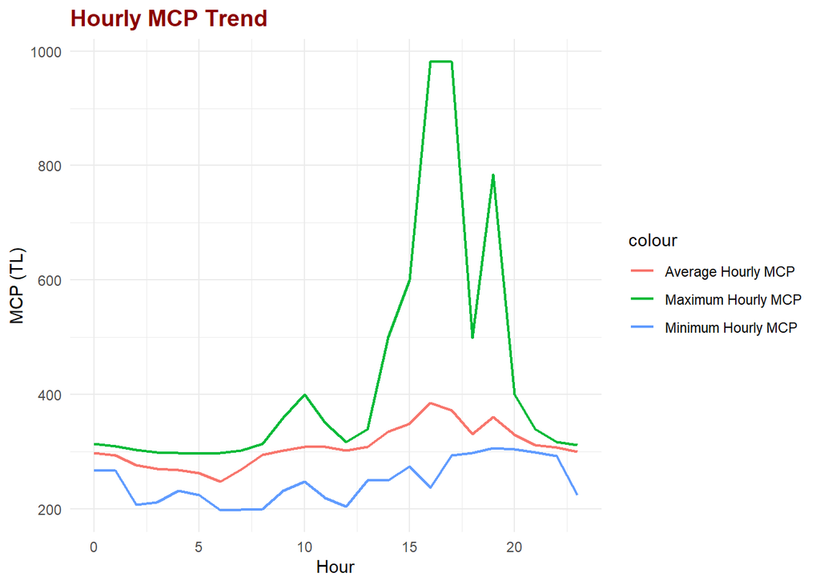

```r
geom_graph <- new_energy_data %>% group_by(Hour) %>%
  summarise(Avg_MCP=mean(MCP), Min_MCP=min(MCP), Max_MCP=max(MCP), Avg_SMP=mean(SMP),
            Min_SMP=min(SMP), Max_SMP=max(SMP))
hourly_mcp<-ggplot(geom_graph, aes(x=Hour)) + geom_line(aes(y=Avg_MCP, color="Average Hourly MCP"), size=0.8) +
              geom_line(aes(y=Min_MCP, color="Minimum Hourly MCP"), size=0.8) +
              geom_line(aes(y=Max_MCP, color="Maximum Hourly MCP"), size=0.8) +
              labs(x="Hour", y="MCP (TL)") + theme_minimal() +
              ggtitle("Hourly MCP Trend")

hourly_mcp + theme(
  plot.title = element_text(color="darkred", size=14, face="bold"))
```

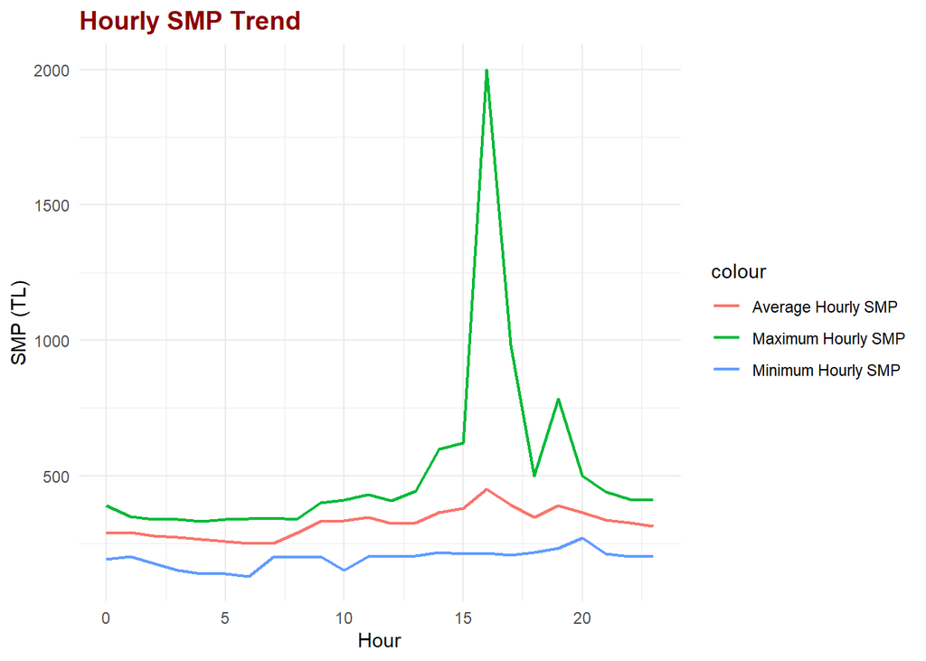

```r
hourly_smp<-ggplot(geom_graph, aes(x=Hour)) + geom_line(aes(y=Avg_SMP, color="Average Hourly SMP"), size=0.8) +
              geom_line(aes(y=Min_SMP, color="Minimum Hourly SMP"), size=0.8) +
              geom_line(aes(y=Max_SMP, color="Maximum Hourly SMP"), size=0.8) +
              labs(x="Hour", y="SMP (TL)") + theme_minimal() +
              ggtitle("Hourly SMP Trend")

hourly_smp + theme(
  plot.title = element_text(color="darkred", size=14, face="bold"))
```

It is seen that the SMP values and the MCP values given in the previous graph move in the same direction. Especially between 4 pm and 5 pm, it is seen that the energy requirement is approximately 4 times the normal energy requirement.

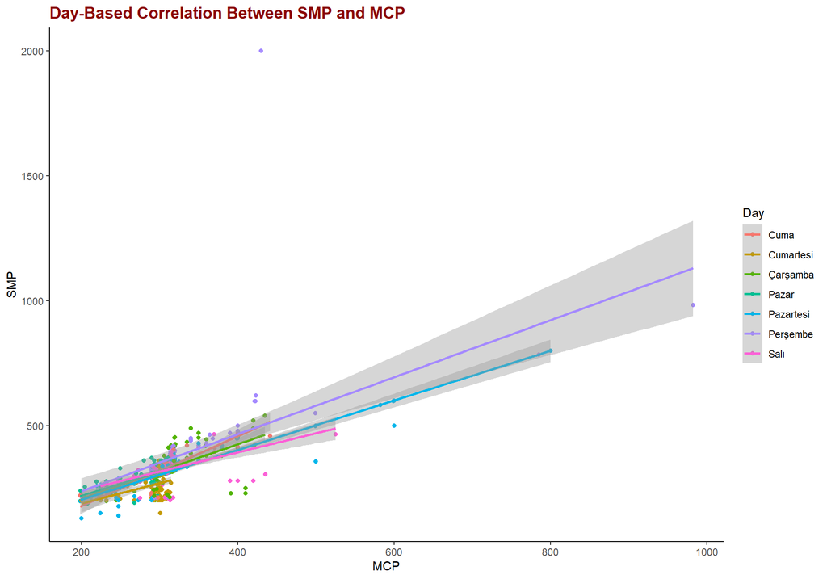

```r
cor<- ggplot(new_energy_data, aes(MCP, SMP, color=Day)) + geom_point() + geom_smooth(method= 'lm') +
        theme_classic() + ggtitle("Day-Based Correlation Between SMP and MCP")

cor + theme(
  plot.title = element_text(color="darkred", size=14, face="bold"))
```

Looking at the day-based of SMP and MCP data, as expected, it was observed that the energy need at the weekend is lower than weekday. The highest energy requirement occurred on Thursday.

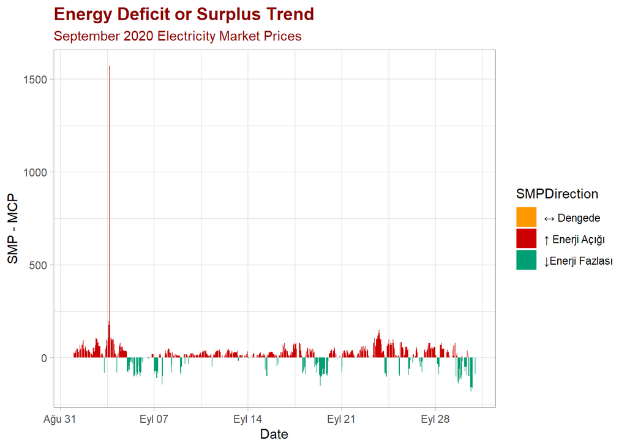

```r
col_graphs<- new_energy_data %>%
  group_by(Date) %>% select(Date, SMP_MCP_Diff, SMPDirection)


diff_smp_mcp<-ggplot(col_graphs, aes(x=Date, y=SMP_MCP_Diff, fill=SMPDirection)) + geom_col() +
                scale_fill_manual("SMPDirection", values=c("#FF9900","#CC0000","#009E73")) +
                labs(x="Date", y="SMP - MCP") + theme_light() +
                ggtitle("Energy Deficit or Surplus Trend", "September 2020 Electricity Market Prices")

diff_smp_mcp + theme(
  plot.title = element_text(color="darkred", size=14, face="bold"),
  plot.subtitle = element_text(color="darkred", size=11))
```